# Simple Phillips Curve

アセット･マネジメント･コンサルティング株式会社 http://am-consulting.co.jp

2017-06-30 11:00:05

- アセット･マネジメント･コンサルティング株式会社 http://am-consulting.co.jp
- SaECaNet http://saecanet.com/
- Olive http://olive.saecanet.com/
- twitter https://twitter.com/AMC2_Japan
- 本ページへのリンクを共有:[Tweet](https://twitter.com/share)
- タイトル : 日本のフィリップス曲線:完全失業率と消費者物価指数:2017年05月:完全失業率(%)-男女計:季節調整値:3.1 , 消費者物価指数前年同月比(%):食料(酒類を除く)及びエネルギーを除く総合:-0.2
- データ出所 : 総務省
- 消費者物価指数を確認する際は次の消費税導入および増税に留意して下さい。
  - 1989年4月：消費税3%の導入。
  - 1997年4月：消費税5%への増税。
  - 2014年4月：消費税8%への増税。
- 本ページ中のフィリップス曲線は単純に
  $$y= a \times x^{b}$$
  として近似したものである。

#### 完全失業率(%)-男女計:季節調整値 × 消費者物価指数前年同月比(%):食料(酒類を除く)及びエネルギーを除く総合

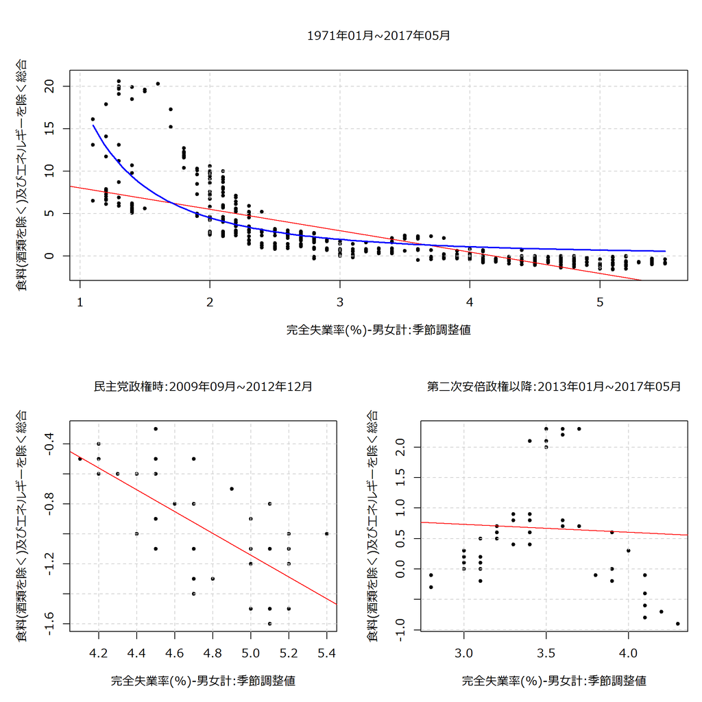

```
## 対象期間 : 1971年01月 ~ 2017年05月
## x : 完全失業率(%)-男女計:季節調整値
## y : 消費者物価指数前年同月比(%):食料(酒類を除く)及びエネルギーを除く総合
## Formula: y ~ a * x^b
##
## Parameters:
##   Estimate Std. Error t value            Pr(>|t|)
## a 18.75978    0.87591   21.42 <0.0000000000000002 ***
## b -2.05604    0.08391  -24.50 <0.0000000000000002 ***
## ---
## Signif. codes:  0 '***' 0.001 '**' 0.01 '*' 0.05 '.' 0.1 ' ' 1
##
## Residual standard error: 2.56 on 555 degrees of freedom
##
## Number of iterations to convergence: 11
## Achieved convergence tolerance: 0.000006443
```

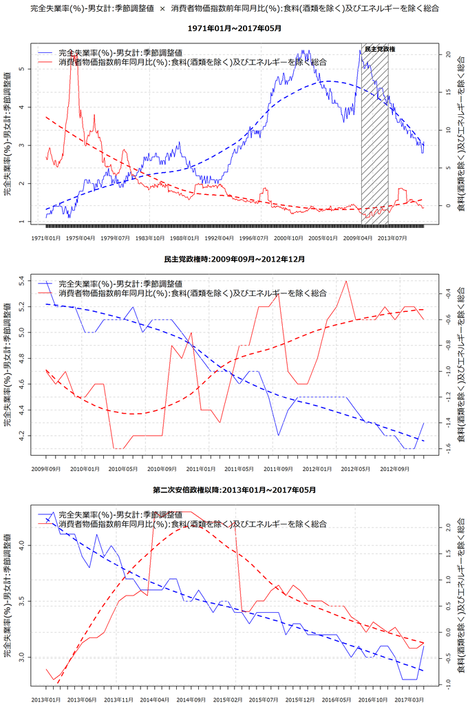

```
## Group: 第二次安倍政権発足以降:2013年01月 ~ 2017年05月
##  完全失業率(%)-男女計:季節調整値
##  Min.   :2.800
##  1st Qu.:3.200
##  Median :3.400
##  Mean   :3.462
##  3rd Qu.:3.700
##  Max.   :4.300
##  消費者物価指数前年同月比(%):食料(酒類を除く)及びエネルギーを除く総合
##  Min.   :-0.9000
##  1st Qu.: 0.0000
##  Median : 0.6000
##  Mean   : 0.6736
##  3rd Qu.: 0.9000
##  Max.   : 2.3000
## ---------------------------------------------------------------------------
## Group: 民主党政権:2009年09月 ~ 2012年12月
##  完全失業率(%)-男女計:季節調整値
##  Min.   :4.100
##  1st Qu.:4.475
##  Median :4.700
##  Mean   :4.715
##  3rd Qu.:5.100
##  Max.   :5.400
##  消費者物価指数前年同月比(%):食料(酒類を除く)及びエネルギーを除く総合
##  Min.   :-1.600
##  1st Qu.:-1.200
##  Median :-0.950
##  Mean   :-0.935
##  3rd Qu.:-0.600
##  Max.   :-0.300
```

| Date | 完全失業率(%)-男女計:季節調整値 | 消費者物価指数前年同月比(%):食料(酒類を除く)及びエネルギーを除く総合 |
| --- | --- | --- |
| 2012年06月 | 4.3 | -0.6 |
| 2012年07月 | 4.3 | -0.6 |
| 2012年08月 | 4.2 | -0.5 |
| 2012年09月 | 4.2 | -0.6 |
| 2012年10月 | 4.1 | -0.5 |
| 2012年11月 | 4.1 | -0.5 |
| 2012年12月 | 4.3 | -0.6 |
| 2013年01月 | 4.2 | -0.7 |
| 2013年02月 | 4.3 | -0.9 |
| 2013年03月 | 4.1 | -0.8 |

[output cut: 50 more lines]

#### 第二次安倍政権発足前後の比較

- 2012年12月:野田政権から安倍第二次政権への交代

| ID | 項目 | 2012年05月 | 2017年05月 | 2012年05月から2017年05月の変化(%またはポイント) |
| --- | --- | --- | --- | --- |
| 1 | 完全失業率(%)-男女計:季節調整値 | 4.4 | 3.1 | -1.3 |
| 2 | 消費者物価指数前年同月比(%):食料(酒類を除く)及びエネルギーを除く総合 | -0.6 | -0.2 | 0.4 |